# Reproducible Analysis of ICES Eggs and Larvae Survey Data Using R and Quarto

Author

Sarah Perché

Published

November 19, 2026

# Objectives

This report demonstrates data processing, integration, analysis, and reproducible reporting using R and Quarto. Using data from the ICES Eggs and Larvae database, fish egg and larval observations from Denmark, Norway, and Sweden were analysed for the period 2016-2026 to explore spatial and temporal patterns in biodiversity.

# Data overview

- Data source: ICES Eggs & Larvae dataset (*ICES Eggs and Larvae dataset [2026]. ICES, Copenhagen)*
- Countries: Denmark, Sweden, Norway
- Period: 2016-2026
- Objective: summarise species richness and diversity patterns in Scandinavian fish egg and larval survey data.

# Import data

```r
file_list <- list.files(
  full.names = TRUE,
  pattern = "\\.(csv|xls|xlsx)$"
)

file_list
```

```
[1] "./EggsAndLarvaeData_EH_1119520234.csv"
[2] "./EggsAndLarvaeData_EM_1119520234.csv"
[3] "./EggsAndLarvaeData_Historical_1119520234.csv"
```

# Data processing

The EH (haul metadata) and EM (egg and larval measurements) datasets were linked using the common identifier *HaulID*. Records were filtered to Denmark, Norway, and Sweden and restricted to observations collected between 2016 and 2026. The resulting dataset contained information on sampling location, species identity, developmental stage, and abundance, which were used to calculate biodiversity indicators.

```r
# Import the three survey datasets
eggs_eh <- read.csv(file_list[1])
eggs_em <- read.csv(file_list[2])
eggs_hi <- read.csv(file_list[3])

# Filter EH
eh_scand <- eggs_eh %>%
  filter(
    Country %in% c("DK","NO","SE"),
    Year >= 2016,
    Year <= 2026
  )

# Join with SI using common keys
final_data <- eh_scand %>%
  left_join(
    eggs_em,
    by = c(
      "HaulID")
  )

# Keep only variables for analysis
final_data <- final_data %>%
  select(
    HaulID,
    Survey,
    Country,
    Month,
    Year,
    Species,
    ELSampleFlag,
    Number
  )

# Summary
summary_table <- final_data %>%
  mutate(
    Country = recode(
      Country,
      "DK" = "Denmark",
      "NO" = "Norway",
      "SE" = "Sweden"
    ),
    Stage = recode(
      ELSampleFlag,
      "EG" = "Egg",
      "LV" = "Larva",
      "JV" = "Juvenile",
      "NS" = "Not specified"
    )
  ) %>%
  group_by(Country) %>%
  summarise(
    Period = paste0(min(Year), "-", max(Year)),
    Species_n = n_distinct(Species),
    Species_List = paste(
      head(sort(unique(Species)), 10),
      collapse = ", "
    ),
    Stage_n = n_distinct(Stage),
    Stage_List = paste(
      sort(unique(Stage)),
      collapse = ", "
    ),
    .groups = "drop"
  )

knitr::kable(
  summary_table,
  caption = "Summary"
)
```

Summary

| Country | Period | Species_n | Species_List | Stage_n | Stage_List |
| --- | --- | --- | --- | --- | --- |
| Denmark | 2016-2026 | 7 | Anguilla anguilla, Clupea harengus, Maurolicus muelleri, Microstomus kitt, Sardina pilchardus, Scomber scombrus, Sprattus sprattus | 4 | Egg, Juvenile, Larva, Not specified |
| Norway | 2016-2026 | 9 | Anguilla anguilla, Clupea harengus, Maurolicus muelleri, Merluccius merluccius, Microstomus kitt, Molva molva, Pisces, Scomber scombrus, Trachurus trachurus | 2 | Egg, Larva |
| Sweden | 2016-2026 | 7 | Anguilla anguilla, Clupea harengus, Clupeidae, Maurolicus muelleri, Microstomus kitt, Sardina pilchardus, Sprattus sprattus | 1 | Larva |

# Biodiversity index

Species richness measures the number of species present in a community, while the Shannon diversity index accounts for both species richness and the relative abundance of each species. Together, these metrics provide complementary measures of biodiversity.

## Species richness

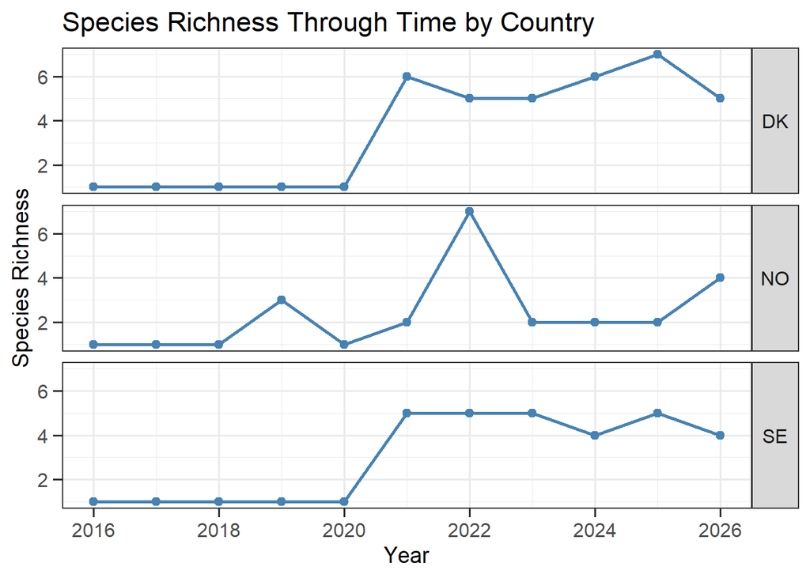

```r
richness_country <- final_data %>%
  group_by(Country, Year) %>%
  summarise(
    Richness = n_distinct(Species),
    .groups = "drop"
  )

ggplot(richness_country,
       aes(x = Year,
           y = Richness)) +
  geom_line(colour = "steelblue",
            linewidth = 1) +
  geom_point(colour = "steelblue",
             size = 2) +
  facet_grid(Country ~ .) +
  plot_base_theme() +
  labs(
    title = "Species Richness Through Time by Country",
    x = "Year",
    y = "Species Richness"
  )
```